# Used car data as predictor for US-Presidential election outcomes

Mai 20<sup>th</sup> 2021

## Agenda

1. Introduction
2. Data gathering & cleaning
3. Descriptive statistics
4. Analytical approaches
5. Linear regression coefficients
6. XGBoost parameter importance
7. Results with XGBoost prediction

## Introduction

The 2020 US-Presidential election led to highest voter turnout in history due to clash of socio-economic groups and ideologies:

### **Donald Trump Vs. Joe Bidden**

Conservative vs. Liberal

Urban vs. Rural

Climate Protectionists vs. Climate Change Deniers

Young vs. old

But are those socio-economic gaps also visible when it comes to the American’s love for big cars?

## Research question

### Do car characteristics have any predictive power for the US-presidential voting outcome?

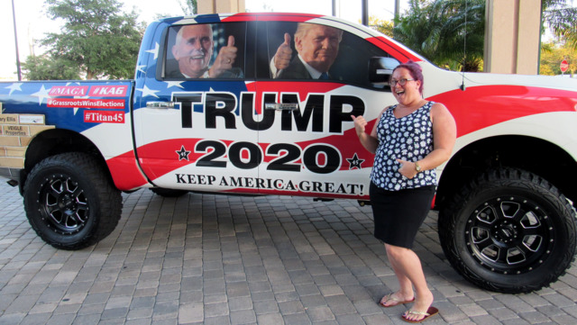

## Data gathering(1/2)

1. Used Car dataset *(Kaggle):* loaded with an out-of-memory approach using the ff-package to store data chunks of 100k observations at a time
   - 3 million cars xlisted on Cargurus as of Sept. 2020 in 1338/3006 counties
   - Each car reported with 66 characteristics
   - resulting in a total of ~200 million data points

## Data merging and cleaning (2/2)

### **Merging:**

Problem : County level voting data vs. longitudonale/lattitudonale level car data

Solution: Package ‘jvamisc’ maps latitudinal & longitudinal car data to county

### **Cleaning approach**

1. Strain splitting, variable type definition and data types were set
2. Visually identified outliers were excluded with an ff out-of-memory approach
   - city fuel economy < 70 miles per gallon
   - highway fuel economy < 60 miles per gallon
   - Horsepower < 600
   - Price < 200’000 $
   - Mileage < 300’000 miles
   - rpm (revolutions per minute) < 2000
   - Savings Amount < 2500
   - year > 1900

## The sample in use (1/2)

### **Dependent variable:**

- democratic to republican voter outcome

\(\frac{democratic\:votes}{democratic\:votes + republican\:votes}\)

### **Independant variables:**

- Is new (if car is new or pre-owned)
- Price
- Fuel economy city (fuel consumption in the city)
- Mileage
- Horsepower
- Length
- Max seating
- Body type
- Brand name
- State

–> **Total sample size:** 2.6mio observations

## Sample in use (2/2)

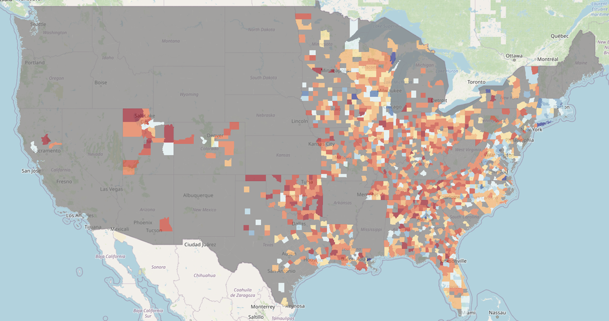

## Analytical approaches

**Linear regression** Normalized values were used

- on CPU
- on GPU
  - gpuLm function from package ‘GPUtools’
  - CUDA for INVIDIA GPUs *(downfall: does not work on other GPUs)*

- In RAM with approximated solutions (“hist” method)
- Out-of-Memory

## Linear regression coefficients and robustness

```
##                           Estimate   Std. Error    t value      Pr(>|t|)
## (Intercept)             0.38340140 0.0113614174  33.745913 1.695187e-249
## StateDemRepRatio        0.38491465 0.0008903375 432.324438  0.000000e+00
## mileage                -0.03822318 0.0015418609 -24.790289 1.253755e-135
## price                  -0.06505141 0.0022602358 -28.780805 4.425654e-182
## city_fuel_economy       0.02747648 0.0016071713  17.096175  1.618959e-65
## horsepower              0.03574419 0.0025072174  14.256520  4.125754e-46
## body_typeMinivan       -0.13102785 0.0095486989 -13.722063  7.557345e-43
## body_typePickup Truck  -0.17910668 0.0081765525 -21.904914 2.470232e-106
## make_nameAudi           0.05310716 0.0127663737   4.159926  3.183777e-05
## make_nameBMW            0.07692295 0.0111795467   6.880686  5.959964e-12
## make_nameMercedes-Benz  0.08156817 0.0111633835   7.306760  2.738619e-13
## make_nameChevrolet     -0.32367202 0.0092861414 -34.855384 5.095822e-266
## make_nameChrysler      -0.33681062 0.0122129260 -27.578209 2.346658e-167
## make_nameDodge         -0.35045809 0.0102633049 -34.146709 2.099159e-255
## make_nameFord          -0.34698505 0.0091915618 -37.750391 1.228648e-311
## make_nameRAM           -0.36690088 0.0108229827 -33.900163 9.204749e-252
```

## XGBoost parameter importance plot

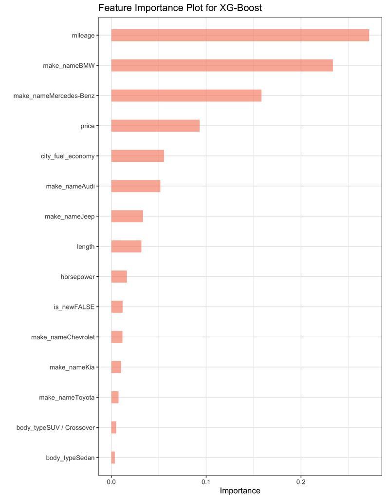

## Sources of Data

https://github.com/MEDSL/2020-elections-official https://www.kaggle.com/ananaymital/us-used-cars-dataset

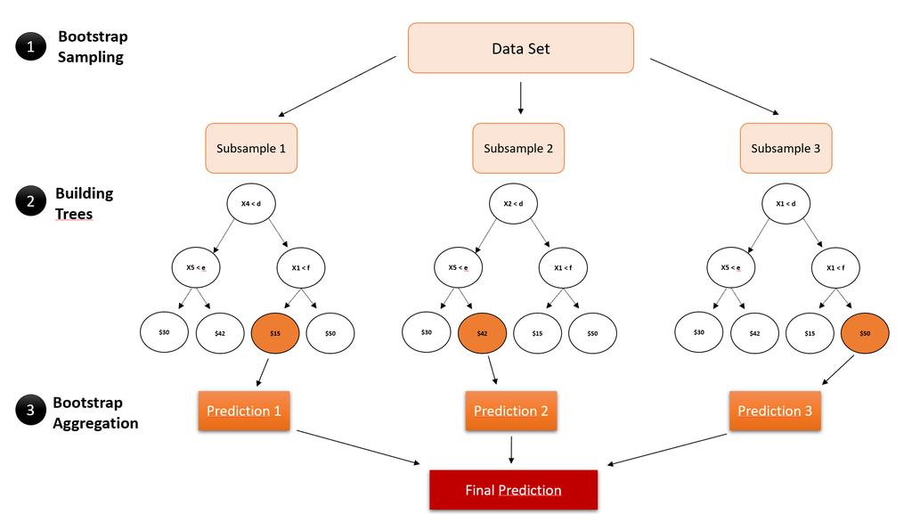

## Actual vs. predicted values (XGBoost)

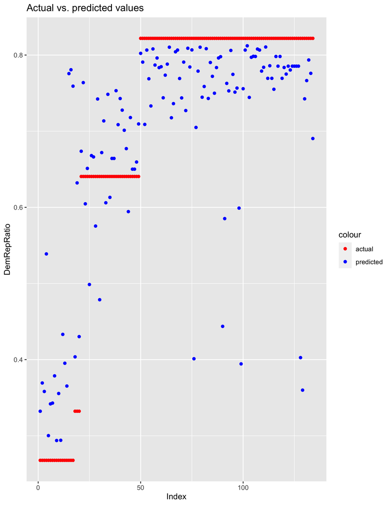